# Technologie wytwarzania elementów urządzeń mechatronicznych

dr hab. inż. Marcin Słoma, prof. PW

Zakład Mikrotechnologii i Nanotechnologii

## TECHNOLOGIA POWŁOK

Powłoka to warstwa materiału wytworzona lub nałożona na powierzchnię elementu w sposób naturalny lub sztuczny. Powłoka jest wykonana z innego materiału niż element. Celem powłoki jest uzyskanie określonych właściwości ochronnych, technicznych lub dekoracyjnych.

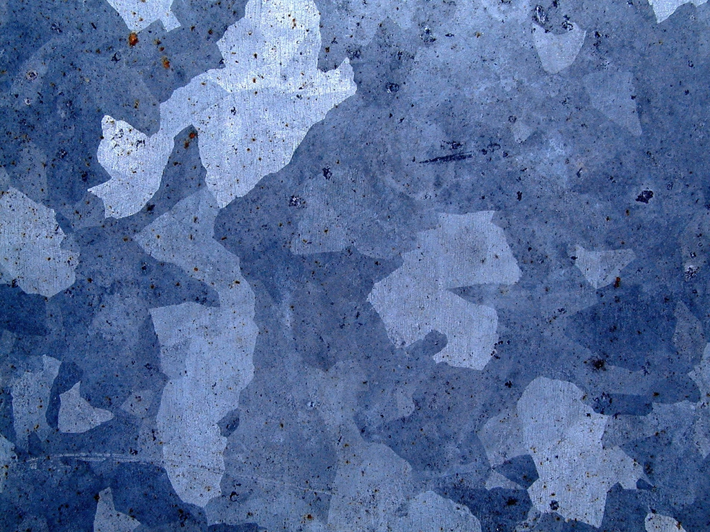

[figure not shown]

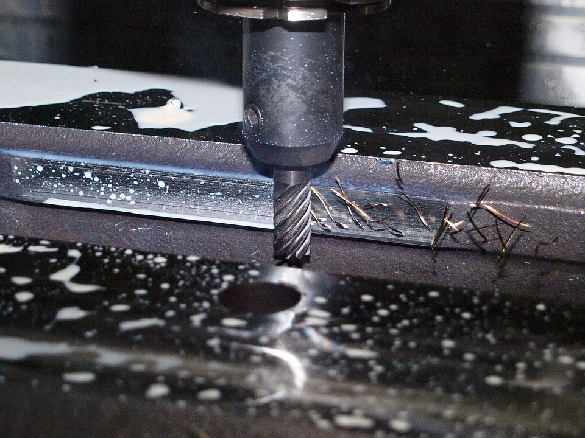

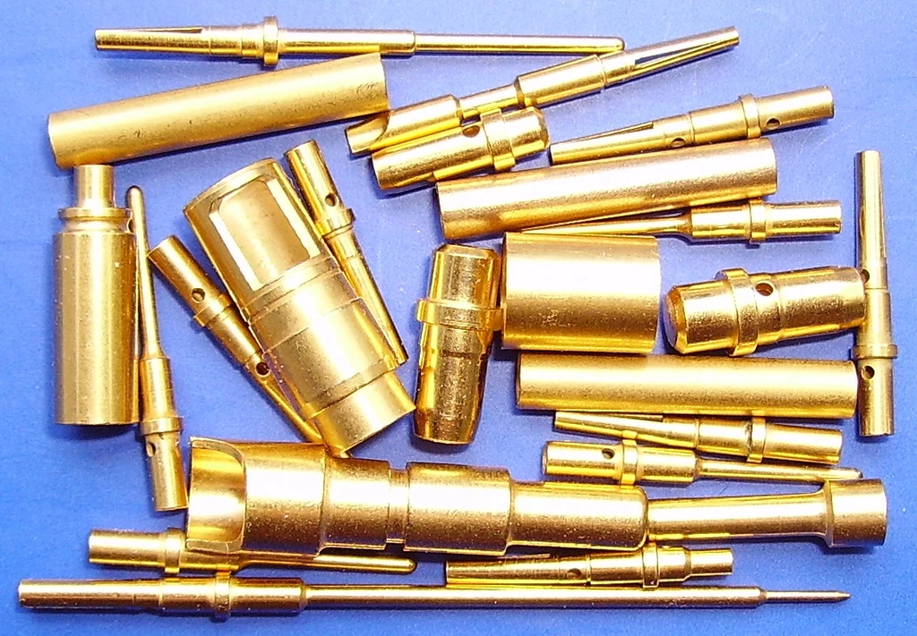

[figure not shown]

[figure not shown]

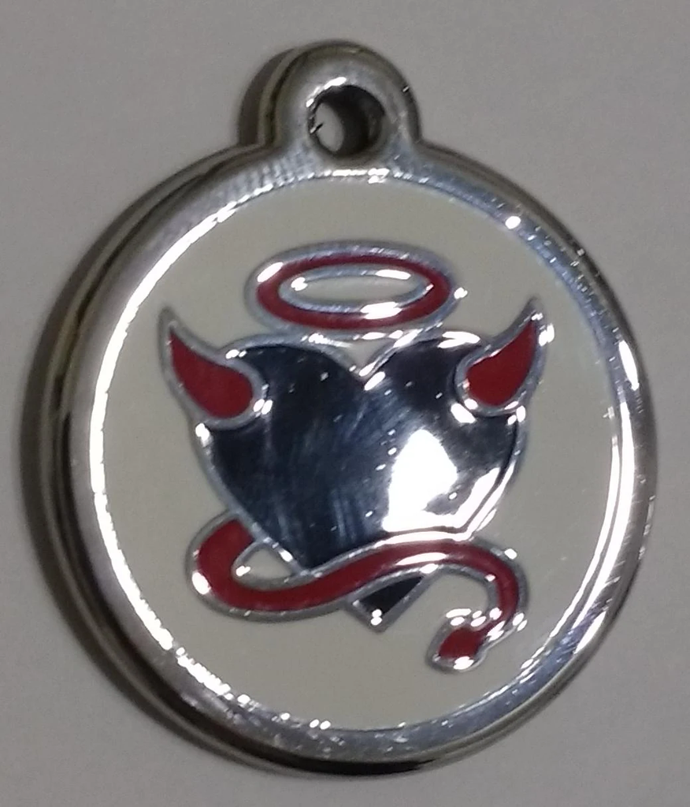

## TECHNIKI WYTWARZANIA POWŁOK

### Powlekanie zanurzeniowe (ogniowe)

- metale lub stopy na podłożach metalowych (lub niemetalach)
- temperatura topnienia powłoki < temperatura topnienia podłoża
  - Sn (232°C), Pb (327°C), Zn (419°C) i Al (660°C) [Fe 1540°C, Cu 1083°C]  
    grubość powłoki 30 - 150 μm

Przykłady zastosowań:

- Zn – zabezpieczenie przed korozją drutów, blach, rur itp.
- Sn – ścieżki PCB (HASL), lutowanie na fali, zabezpieczenia antykorozyjne w przemyśle spożywczym.
- Al – zabezpieczenie elementów pracujących w agresywnych gazach w wysokiej temperaturze.
- Pb – zabezpieczenie antykorozyjne elementów przed agresywnymi chemikaliami, np. H<sub>2</sub>SO<sub>4</sub>.

## TECHNIKI WYTWARZANIA POWŁOK

### Powlekanie zanurzeniowe (proces)

- obróbka wstępna: usuwanie zanieczyszczeń, odtłuszczanie, trawienie i płukanie,
- zanurzenie w topniku (topnikowanie): oczyszczenie z tlenków i zapobieganie ponownemu utlenianiu, ułatwienie zwilżenia powierzchni przez ciekły metal,
- nakładanie powłoki metalowej: zanurzenie lub przeciąganie elementów przez stopiony metal, kontrola zwilżalności pokrywanego metalu (topnik) oraz stanu powlekanej powierzchni, regulacja grubości powłoki przez
- zgarnianie lub zdmuchiwanie nadmiaru ciekłego metalu,
- obróbka końcowa (wyrównanie grubości, wygładzenie, poprawa właściwości i wyglądu – o. cieplna).

## TECHNIKI WYTWARZANIA POWŁOK

### Powlekanie zanurzeniowe (proces)

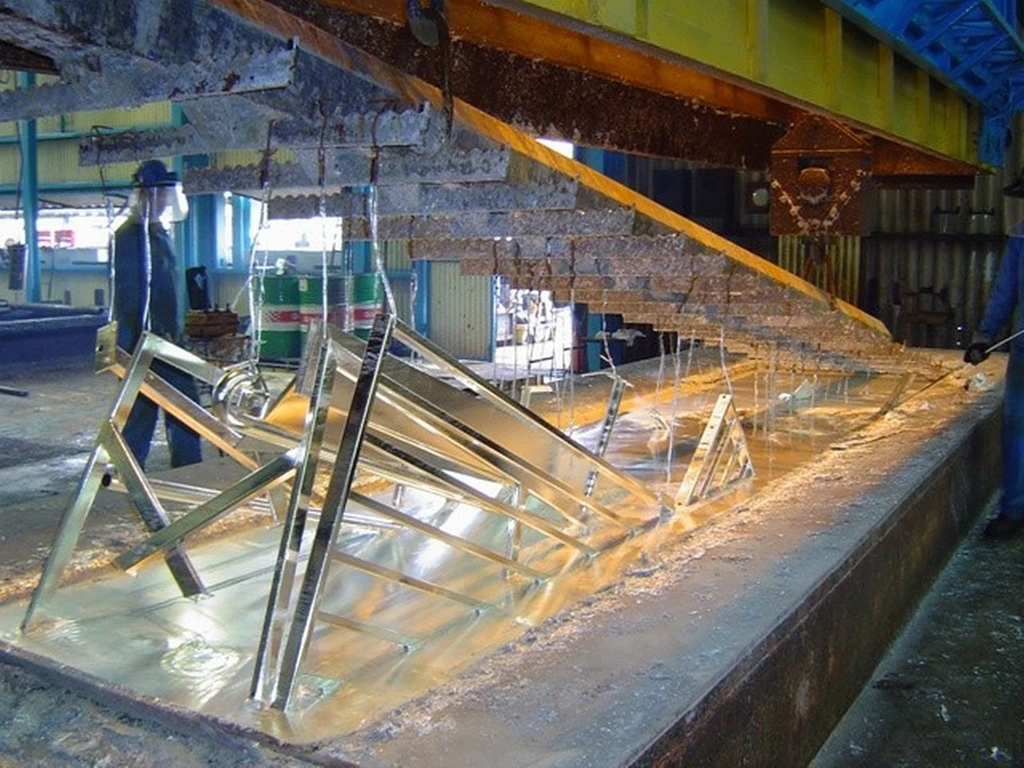

[figure not shown]

1 – walec kierujący blachę, 2 – topnik,  
3 – stopiona cyna, 4 – olej chłodzący

Nepean

## TECHNIKI WYTWARZANIA POWŁOK

### Powlekanie zanurzeniowe (proces)

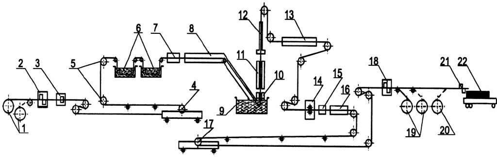

## TECHNIKI WYTWARZANIA POWŁOK

### Powlekanie zanurzeniowe (proces i charakterystyka)

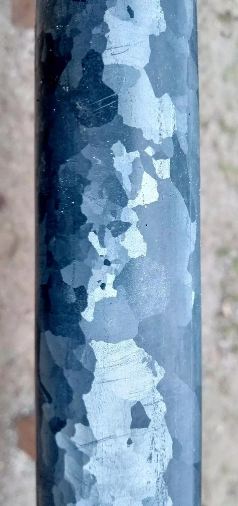

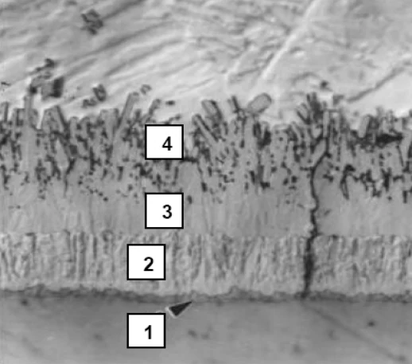

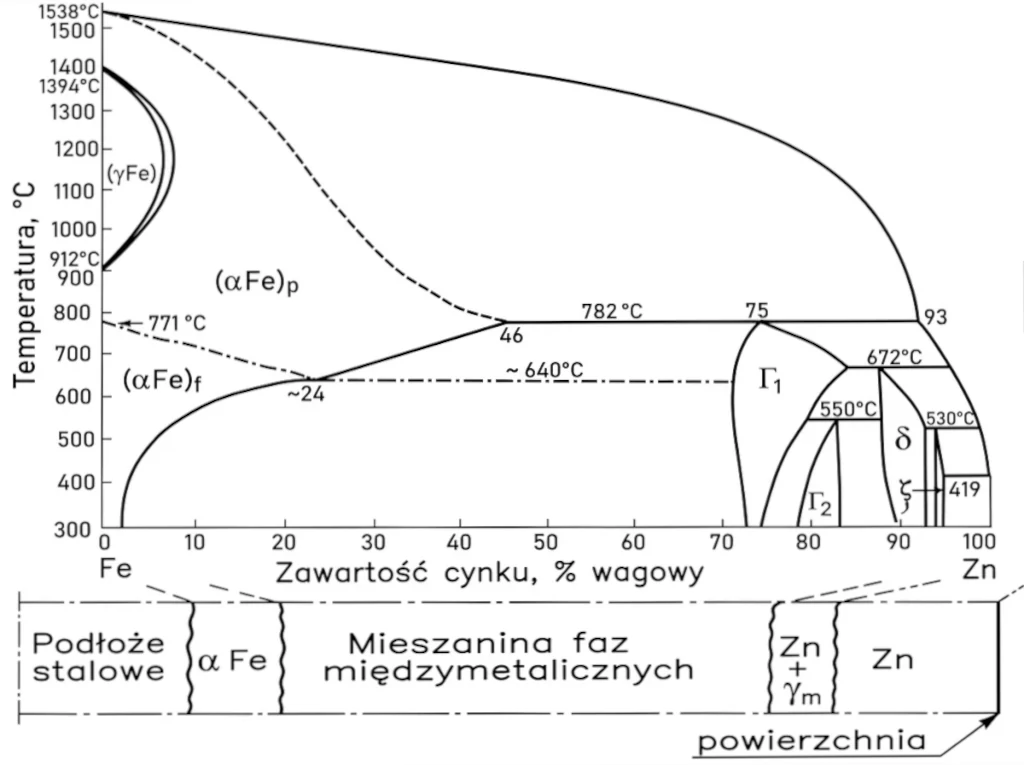

1 – faza gamma Γ 2 – faza delta δ 3 – faza dzeta ζ 4 – cynk

## TECHNIKI WYTWARZANIA POWŁOK

### Powlekanie zanurzeniowe (proces)

[interactive chart not shown]

Factories in Poland https://www.youtube.com/watch?v=6OLz1t4bPPA&t=83s (do samodzielnego oglądania zalecane włączenie dźwięku)

## TECHNIKI WYTWARZANIA POWŁOK

### Powlekanie zanurzeniowe (proces)

[interactive chart not shown]

Epec Engineered Technologies https://www.youtube.com/watch?v=KUP9Flhn_5o

## TECHNIKI WYTWARZANIA POWŁOK

### Powlekanie natryskowe

- stopienie metalu powłoki w płomieniu gazu, w łuku elektrycznym, w plazmie, …,
- rozpylenie pneumatyczne i nadanie dużej energii kinetycznej,
- wywarcie nacisku umożliwiające dobrą przyczepność powłoki do podłoża,
- warstwy Zn, Al, Ni-Cr na podłożach metalowych lub ceramicznych.

[figure not shown]

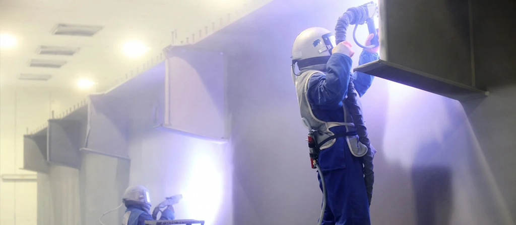

Castolin, Mostostal

## TECHNIKI WYTWARZANIA POWŁOK

### Powlekanie natryskowe (proces)

- podawanie materiału w stanie stałym (proszek, drut, taśma) do strefy topienia,
- ciągłe topienie i rozpylanie metalu sprężonym gazem (powietrze, gazy spalinowe): t ~ 10<sup>-3</sup> s,
- lot stopionych cząstek kulistych z dyszy w kierunku powierzchni (utlenienie powierzchniowe),
- tworzenie powłoki: zetknięcie cząstek z powierzchnią aż do ostygnięcia powłoki.

Rodzaje powlekania natryskowego metali:

- płomieniowe*
- detonacyjne*
- naddźwiękowe (też detonacyjne)
- elektryczne łukowe
- plazmowe
- laserowe

## TECHNIKI WYTWARZANIA POWŁOK

### Powlekanie natryskowe (proces)

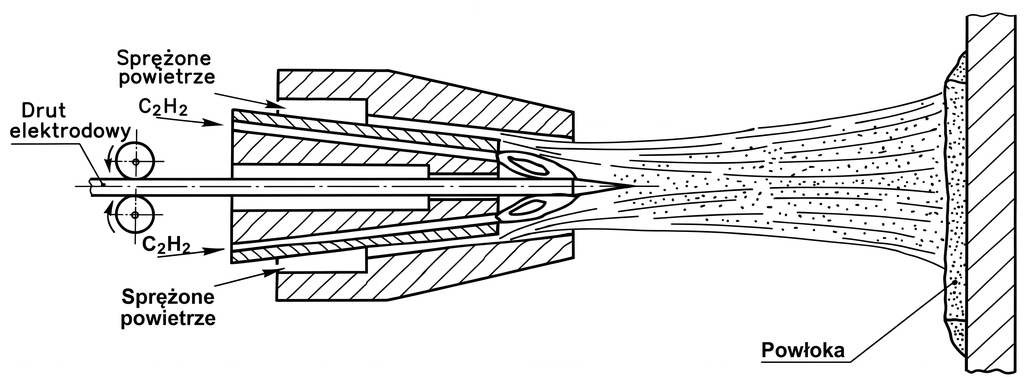

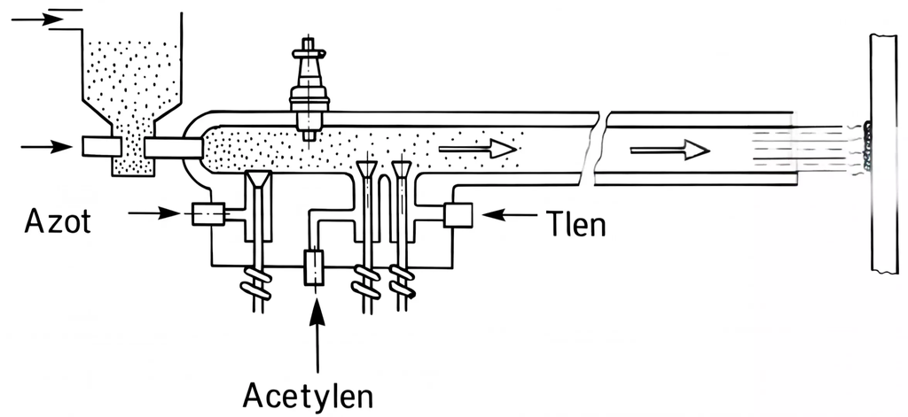

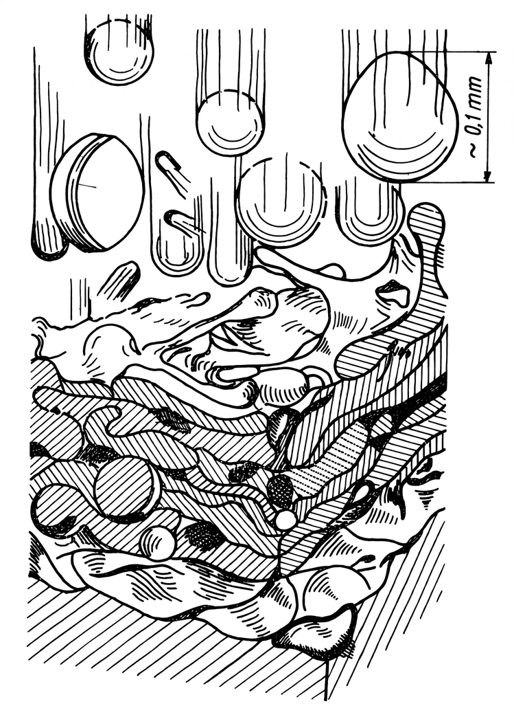

## TECHNIKI WYTWARZANIA POWŁOK

### Powlekanie natryskowe (proces)

[interactive chart not shown]

marekd70 https://www.youtube.com/watch?v=o_9bIGInAPw Plasma Nowa https://www.youtube.com/watch?v=4xfmsXHYtrg&t=52s

## TECHNIKI WYTWARZANIA POWŁOK

### Powlekanie natryskowe (proces)

[interactive chart not shown]

PNC s.c. https://www.youtube.com/watch?v=pjSi7nSfMkc&t=24s VIRT https://www.youtube.com/watch?v=LhN2PUJw_fo

## TECHNIKI WYTWARZANIA POWŁOK

### Platerowanie (*cladding*)

Trwałe łączenie materiału podłoża (metalu lub polimeru) z warstwą powłokową (folią lub arkuszem metalu/stopu) bez użycia prądu elektrycznego. Połączenie powstaje przez wywarcie silnego nacisku (np. walcowanie, detonacja) i utworzenie trwałych wiązań międzyatomowych (metalurgicznych lub adhezyjnych).

- Grubość powłoki: Zależy od grubości użytego materiału i wynosi zazwyczaj od 0,25 do 3 mm (znacznie więcej niż w galwanotechnice).
- Platerowanie na zimno: Walcowanie, tłoczenie, przeciąganie, platerowanie wybuchem oraz bębnowe platerowanie kuleczkowe.
- Platerowanie na gorąco: Walcowanie, przeciąganie, wylewanie, natapianie, napawanie, spiekanie (zgrzewanie dyfuzyjne) oraz laminowanie termiczne (np. folie metalowe na podłożach polimerowych).
- Główne zalety: Możliwość łączenia niekompatybilnych materiałów (np. stal–tytan, miedź–polimer), brak kruchości wodorowej oraz wysoka odporność powłok.

## TECHNIKI WYTWARZANIA POWŁOK

### Platerowanie

[interactive chart not shown]

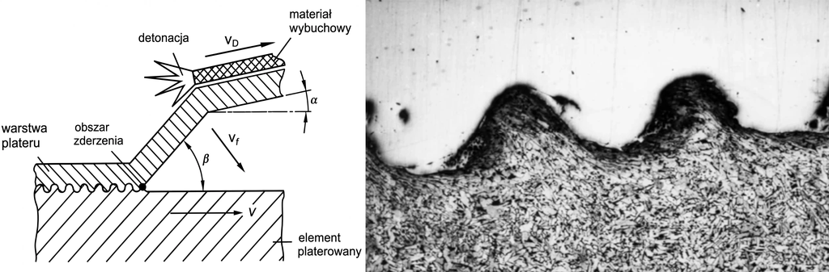

GrafEngin https://www.youtube.com/watch?v=ciCxNgROtm4&t=16s NobelClad https://www.youtube.com/watch?v=u9_bqafUJfA&t=28s ADTW Study https://www.youtube.com/watch?v=d87dd5T2yYg&t

## TECHNIKI WYTWARZANIA POWŁOK

### Powłoki naparowywane

Chemiczne osadzanie z fazy gazowej CVD (Chemical Vapor Deposition)

Prekursor powłoki jest wprowadzany do całej objętości komory reaktora, a kontrola przepływu, stężenia, temperatury procesu i ciśnienia, zapewnia nam kontrolę nad składem powłoki. Cząstki prekursora w bliskości warstwy wierzchniej osadzają się na niej w wyniku reakcji chemicznych.

Fizyczne osadzanie z fazy gazowej PVD (Physical Vapor Deposition)

Atomy lub cząsteczki powłoki są dostarczane na powierzchnię w postaci par lub kinetycznie, w komorze reaktora będącej pod obniżonym ciśnieniem. Powłoka powstaje na powierzchni w wyniku zjawisk fizycznych.

- naparowywanie próżniowe,
- rozpylanie katodowe, rozpylanie magnetronowe (sputtering),
- epitaksja z wiązek molekularnych.

## TECHNIKI WYTWARZANIA POWŁOK

### Powłoki naparowywane

Chemiczne osadzanie z fazy gazowej CVD (Chemical Vapor Deposition)

- wysoka temperatura podłoża zapewnia dobrą przyczepność i utworzenie litej warstwy (900÷1200°C)
- do pokrywania narzędzi z węglików spiekanych (warstwy TiN )
- warstwy diamentowe i diamentopodobne
- grafen epitaksjalny
- elementy mikroelektroniczne oraz optoelektroniczne
- pokrycia materiałów ceramicznych.

## TECHNIKI WYTWARZANIA POWŁOK

### Powłoki naparowywane

Chemiczne osadzanie z fazy gazowej CVD (Chemical Vapor Deposition)

[figure not shown]

## TECHNIKI WYTWARZANIA POWŁOK

### Powłoki naparowywane

Warstwy diamentowe (Diamond Film) i diamentopodobne (Diamond Like Carbon)

## TECHNIKI WYTWARZANIA POWŁOK

### Powłoki naparowywane

Warstwy diamentowe (Diamond Film) i diamentopodobne (Diamond Like Carbon)

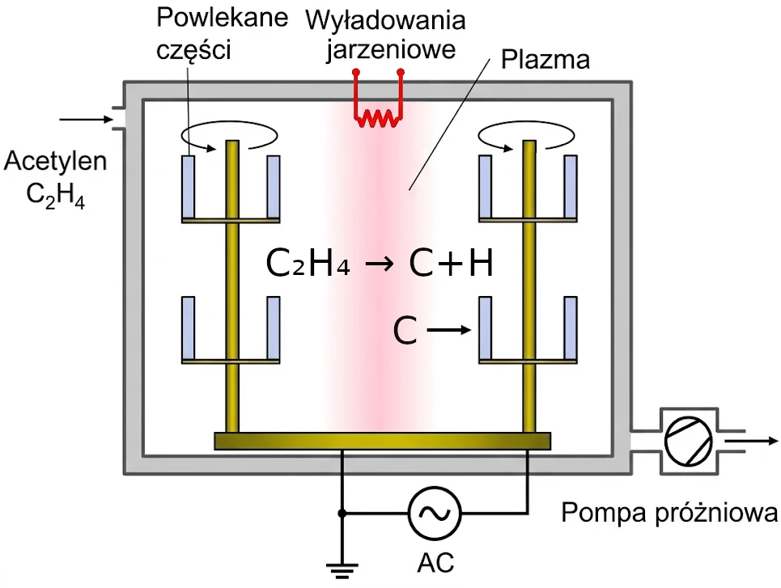

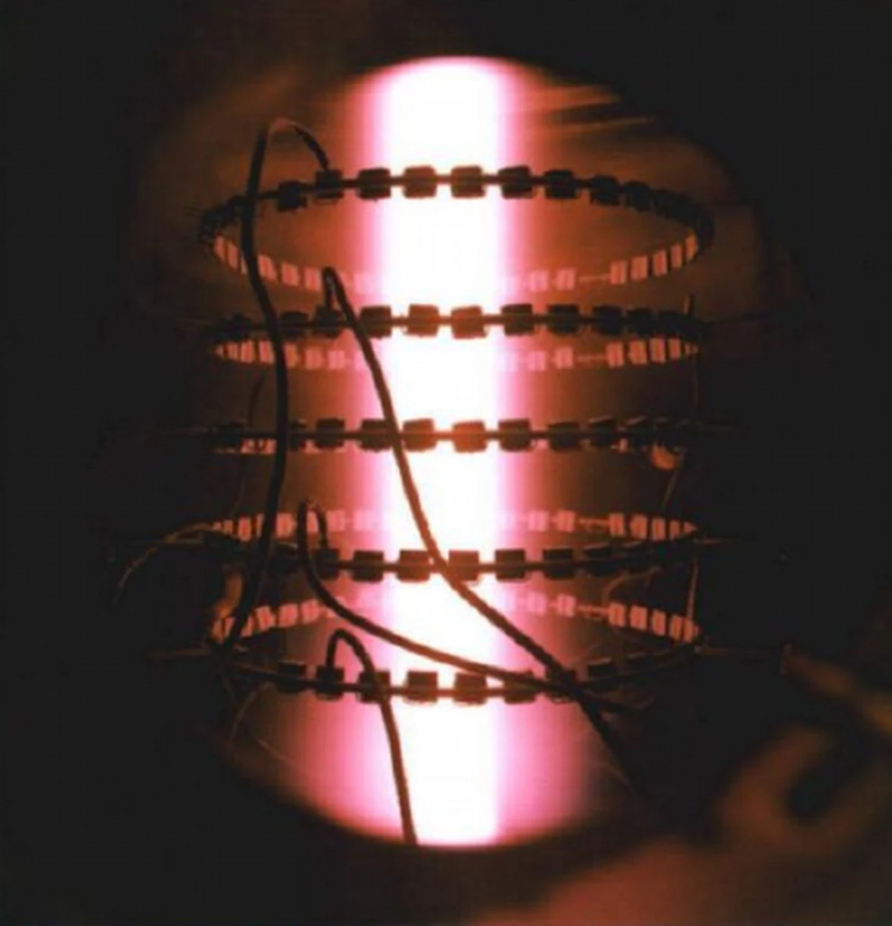

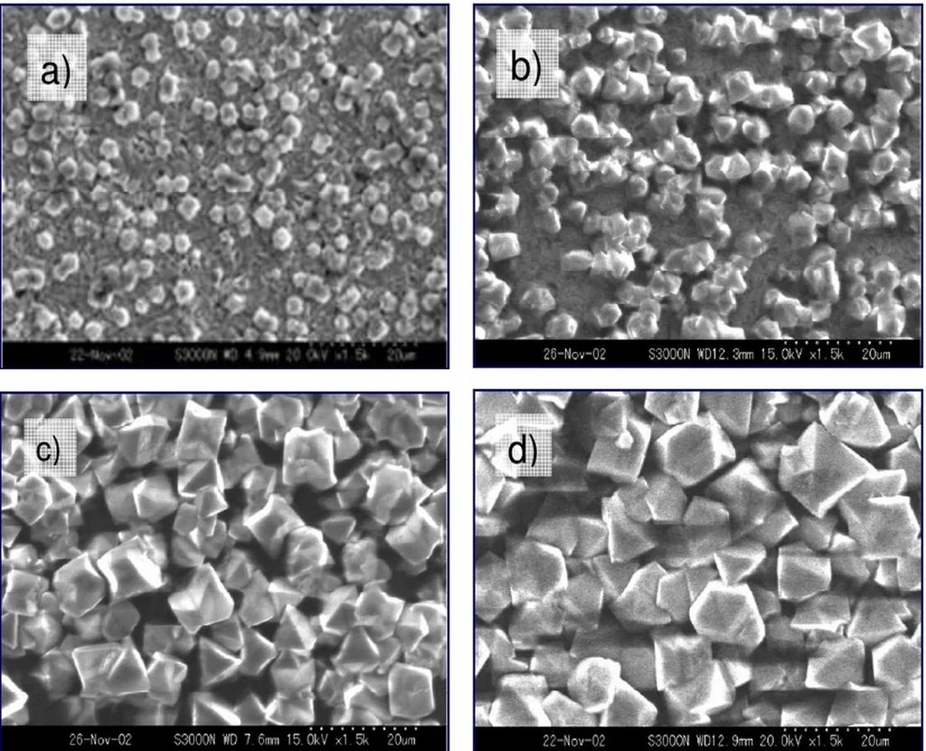

Balzers, Mitsubishi

## TECHNIKI WYTWARZANIA POWŁOK

### Powłoki naparowywane

Fizyczne osadzanie z fazy gazowej PVD (Physical Vapor Deposition)

Naparowanie próżniowe

- Na pokrywanej powierzchni następuje kondensacja materiału, podgrzanego do temperatury parowania.
- Al 119°C (1000Pa), 660°C/2450°C
- Cu 127°C (1000Pa), 1083°C/2595°C
- Cr 92°C (1000Pa), 1875°C/2665°C
- Au 117°C (1000Pa), 1063°C/2970°C

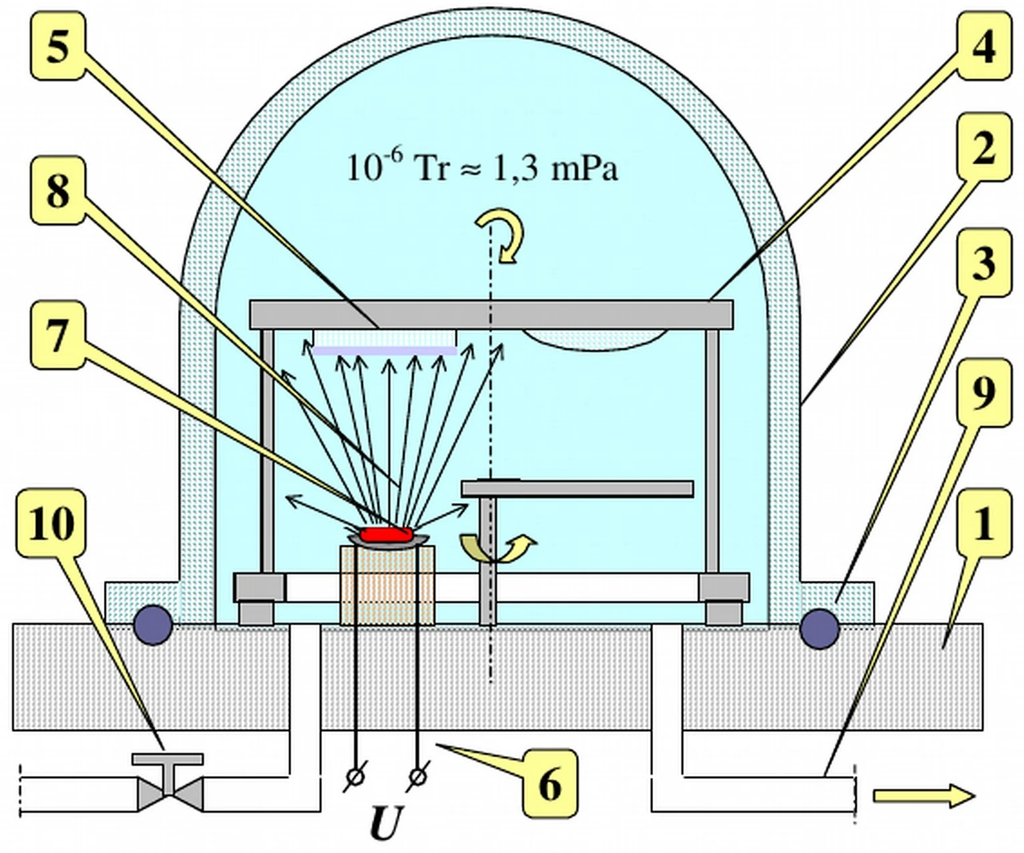

## TECHNIKI WYTWARZANIA POWŁOK

### Powłoki naparowywane

Fizyczne osadzanie z fazy gazowej PVD (Physical Vapor Deposition)

Rozpylanie katodowe

Zjawisko parowania bądź wytrącania cząstek metalu katody pod wpływem bombardowania jonowego w rozrzedzonej atmosferze gazu szlachetnego (jarzeniowe).

Rozpylanie magnetronowe

Jony gazu obojętnego przyspieszane w polu magnetycznym

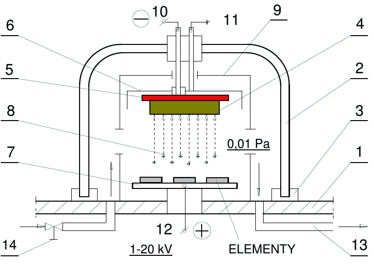

## TECHNIKI WYTWARZANIA POWŁOK

### Powłoki naparowywane

Fizyczne osadzanie z fazy gazowej PVD (Physical Vapor Deposition)

Rozpylanie katodowe, Rozpylanie magnetronowe

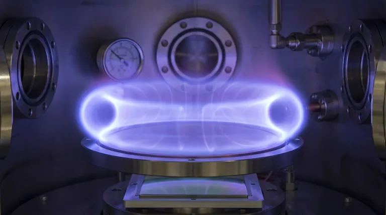

Kintech

## TECHNIKI WYTWARZANIA POWŁOK

### Powłoki naparowywane

Fizyczne osadzanie z fazy gazowej PVD (Physical Vapor Deposition)

Epitaksja z wiązek molekularnych MBE (Molecular Beam Epitaxy)

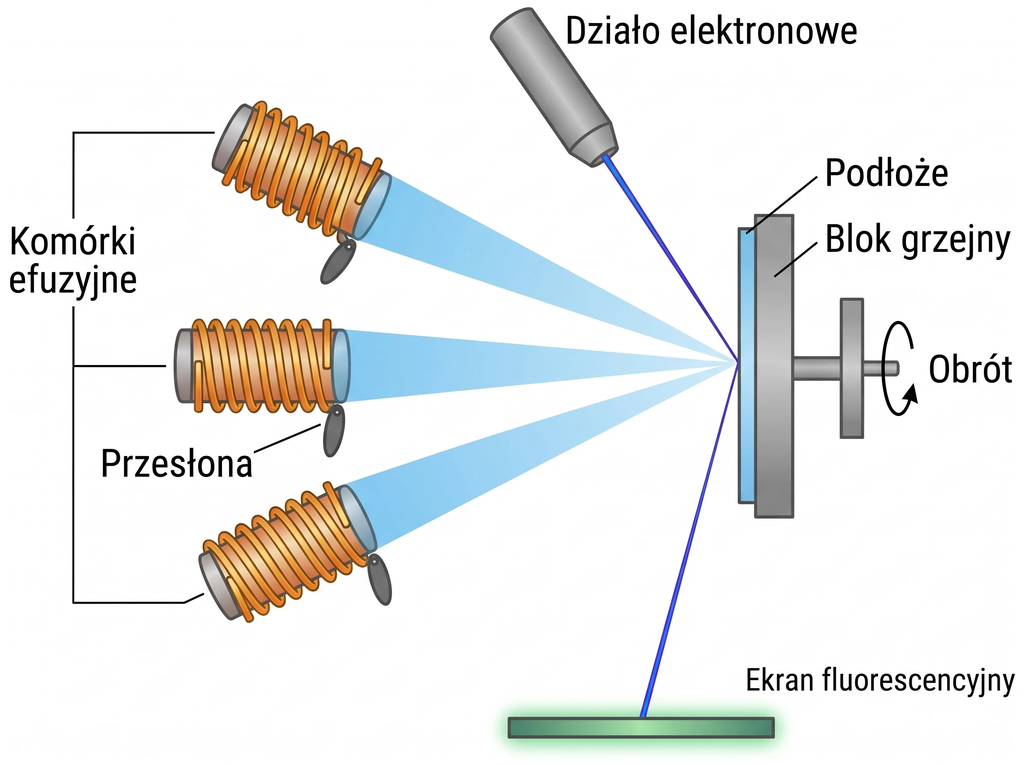

## TECHNIKI WYTWARZANIA POWŁOK

### Powłoki naparowywane (zastosowanie)

- w optyce: przeciwodblaskowe (MgF<sub>2</sub>, CaF<sub>2</sub>) i odblaskowe (Al, Cr, Au), filtry,
- w elektronice: przewodzące, (Al), rezystywne (Ni, Cr), dielektryczne (SiO<sub>2</sub>), magnetyczne (FeNiCo),
- warstwy ścierne narzędzi (TiN, TiCN),

[figure not shown]

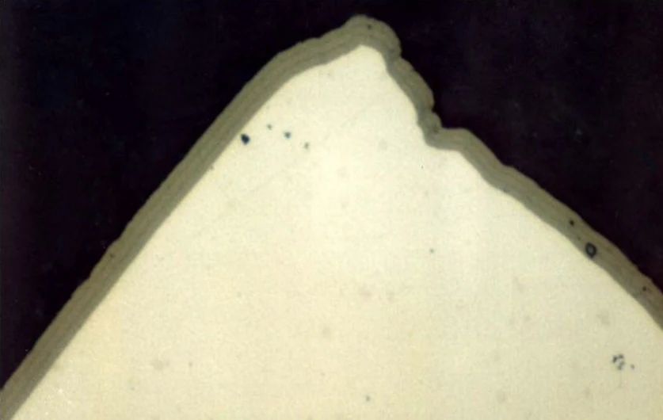

[figure not shown]

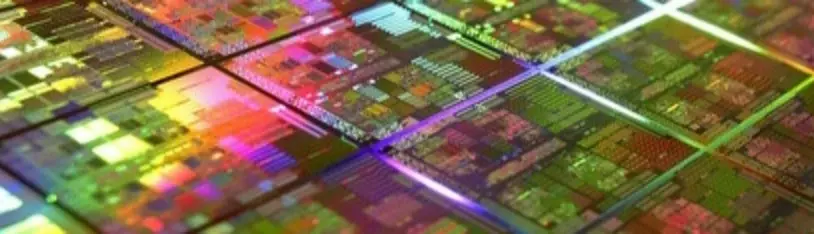

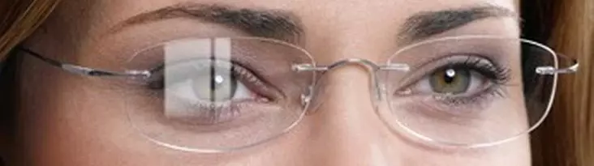

Vacaero, Templeman Opticians, UTexas

## TECHNIKI WYTWARZANIA POWŁOK

### Nasycanie dyfuzyjne

- nasycanie warstwy wierzchniej metali pierwiastkami obcymi
- w ośrodkach stałych, ciekłych lub gazowych
- zmiany składu chemicznego, struktury i właściwości

Przykłady procesów: aluminiowanie, chromowanie, tytanowanie, wanadowanie, cynkowanie, nawęglanie, azotowanie, borowanie, chromoaluminiowanie, chromokrzemowanie, borochromowanie, węglotytanowanie, węgloazotowanie, węgloazototytanowanie

Nasycanie dyfuzyjne w ośrodku ciekłym jest podobne do pokrywania zanurzeniowego – dłuższy czas umożliwia jonom dyfuzję na większą głębokość.

Stężenie jonów do 50 % w warstwie o grubości poniżej 1 mm. Im bliżej powierzchni tym stężenie jest większe, aż do pełnego pokrycia metalem powłoki w przypadku stosowania ośrodków ciekłych.

## TECHNIKI WYTWARZANIA POWŁOK

### Nasycanie dyfuzyjne (przykłady)

- Aluminiowanie
  - stałe: proszek Al, Al<sub>2</sub>O<sub>3</sub>, żelazoglin, kaolin; 850÷1050°C; azot, wodór; t = 1÷10 h (rozmiar elementów)
  - ciekłe: 92÷94 % Al i 6÷8 % Fe; 750÷800°C; t = 0,5÷1h,
  - gazowe: proszek Al, Al<sub>2</sub>O<sub>3</sub>, chlorek amonu; 900÷1050°C; azot, wodór; t = 2 h.
- Chromowanie
  - stałe: żelazochrom lub chrom, chlorek amonowy, piasek kwarcowy, kaolin; 950°C,
  - ciekłe: chlorek chromu, chlorek sodu i żelazochrom; 950÷1000°C,
  - gazowe: chlorek chromu; 950÷1000°C.
- Chromoaluminiowanie
  - stałe: aluminium, żelazochrom; argon, azot lub wodór; 950÷1000°C; 5÷10 h,
  - gazowe: halogenki chromu i glinu; argon, azot lub wodór; 950÷1000°C; 5÷10 h.
  - Azotowanie: gazowe (amoniak, 10÷130 h, 550°C); twardość, odporności na korozję; azotki metali (Fe<sub>4</sub>N).
  - Nawęglanie: dla stali niskowęglowej (<0,25%), zwiększenie twardość zachowując elastyczny rdzeń. Zawartość węgla do 1÷1,3% (0,5÷2 mm); proszkowe, gazowe, ciekłe, 950°C, 10 h, konieczne hartowanie.

## TECHNIKI WYTWARZANIA POWŁOK

### Nasycanie dyfuzyjne (przykłady)

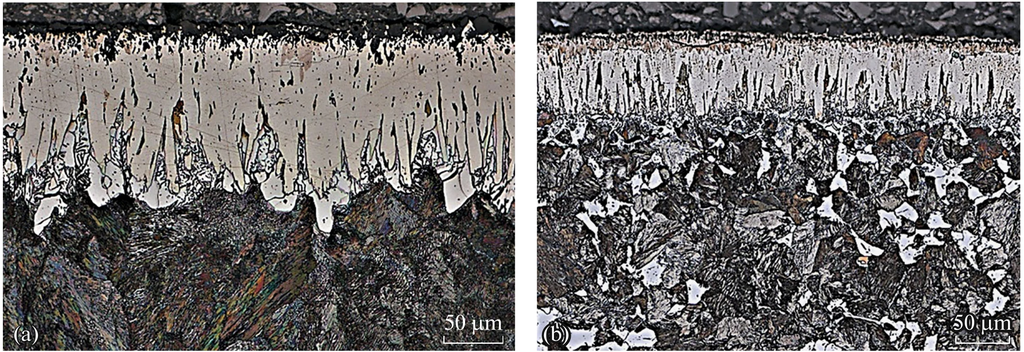

Powłoka dyfuzyjna uzyskana w wyniku kompleksowego nasycania borem, chromem i tytanem: (a) na stali 45, (b) na stali 38Kh2MYuA

Guryev, M. A., et al. “Influence of the chemical composition of steel on the structure and properties of diffusion coatings obtained by simultaneous saturation of structural steels with Boron, Chromium, and Titanium.” Physics of the Solid State 65.1 (2023): 62-65.

## QUIZ

- Jak przeprowadza się powlekanie zanurzeniowe (ogniowe) elementów metalowych?
- Jak przeprowadza się powlekanie natryskowe stopionymi proszkami metali?
- W jaki sposób prowadzi się nasycanie dyfuzyjne?
- W jakim celu obniża się ciśnienie atmosferyczne w procesach naparowania?
- W jaki sposób wytwarza się warstwy węglowe, diamentowe, diamentopodobne i grafen na metalach?